# Cyclistic Bike-Share Analysis

Onyedikachukwu Okonkwo

2025-10-31

## Executive Summary

This analysis examines usage patterns between casual riders and annual members of Cyclistic bike-share to inform marketing strategies for converting casual riders into annual members.

**Key Findings:** - Casual riders take longer trips (22.6 min avg) but members ride 12x more frequently - Members peak on weekdays, casuals peak on weekends - Casuals take round trips 8.8x more often than members

These patterns suggest casual riders use bikes for leisure/recreation while members use them for daily commuting.

## Business Question

**How do annual members and casual riders use Cyclistic bikes differently?**

This analysis uses Q1 2019 and Q1 2020 Divvy trip data (770,000+ rides) to identify behavioral differences between Casuals, and Members that can inform targeted marketing campaigns.

## Finding 1: Duration vs. Frequency

Casual riders take significantly longer trips, but members ride much more frequently.

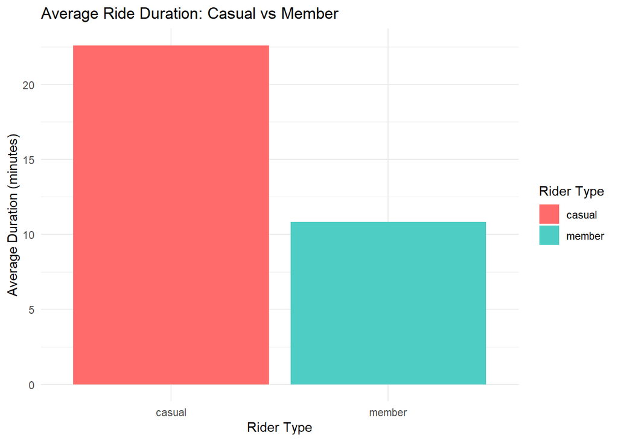

**Insight:** Casual riders average 22.6 minutes per trip compared to members’ 10.8 minutes, suggesting leisurely rides. However, members take 714,215 total trips versus casuals’ 58,316 trips - a 12x difference indicating daily usage patterns.

## Finding 2: Weekly Patterns

Members and casuals show opposite weekly patterns.

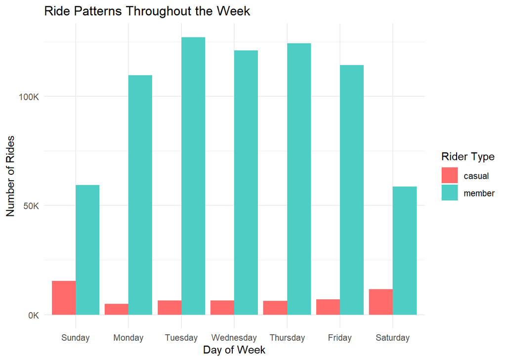

**Insight:** Members peak on weekdays (Tuesday: 127K rides) and drop on weekends, consistent with commuting behavior. Casuals peak on weekends (Sunday: 15K rides) and stay low during weekdays, consistent with recreational use.

## Finding 3: Round Trip Behavior

Casuals are far more likely to return to their starting station.

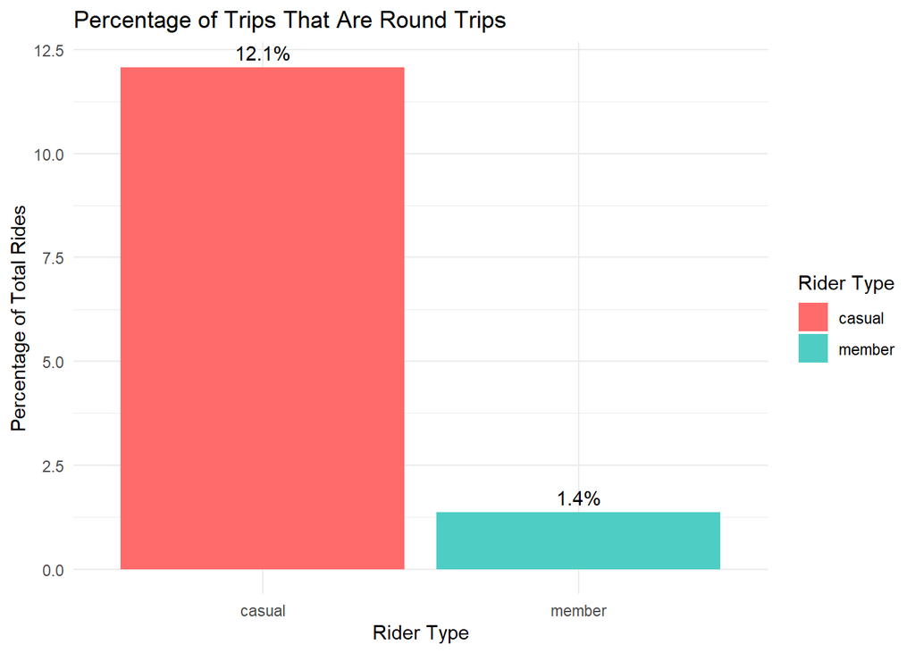

**Insight:** 12.1% of casual trips are round trips compared to only 1.4% of member trips. This supports the leisure vs. commute hypothesis - casuals explore and return, members travel point-to-point.

## Finding 4: Total Usage

Members dominate total ridership.

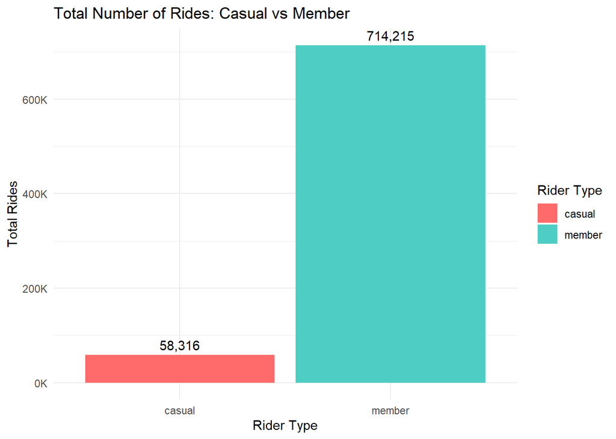

**Insight:** With 714,215 trips versus 58,316, members account for 92% of total rides, making them the primary user base despite having shorter individual trip durations.

## Recommendations

Based on these behavioral differences, marketing strategies to convert casual riders should consider:

1. **Value Proposition Challenge:** Casuals use bikes for occasional leisure, not daily commuting. Traditional annual memberships may not appeal to this usage pattern.
2. **Potential Strategies:**
   - Create weekend/seasonal pass options tailored to leisure riders
   - Develop campaigns showing how bikes can replace short commutes
   - Offer trial periods that encourage behavioral change toward weekday usage
3. **Target Messaging:** Emphasize flexibility, cost savings for weekend warriors, or lifestyle benefits of incorporating bikes into daily routines.

## Methodology

**Data:** Divvy Trips Q1 2019 & Q1 2020 (combined dataset)  
**Tools:** R, tidyverse, ggplot2  
**Process:** Data cleaning, outlier removal (rides <1 min or >60 min), comparative analysis  
**Sample Size:** 772,531 rides analyzed